# MovieLens Project Questions

### Project - MovieLens Data Analysis

The GroupLens Research Project is a research group in the Department of Computer Science and Engineering at the University of Minnesota. The data is widely used for collaborative filtering and other filtering solutions. However, we will be using this data to act as a means to demonstrate our skill in using Python to “play” with data.

#### Domain

Internet and Entertainment

**Note that the project will need you to apply the concepts of groupby and merging extensively.**

Github link: https://github.com/mazeeblanke/Movie-Lens

#### 1. Import the necessary packages - 2.5 marks

```python
import numpy as np
import pandas as pd
import seaborn as sns
import matplotlib.pyplot as plt
```

#### 2. Read the 3 datasets into dataframes - 2.5 marks

```python
data = pd.read_csv('Data.csv')
item = pd.read_csv('item.csv')
user = pd.read_csv('user.csv')
```

#### 3. Apply info, shape, describe, and find the number of missing values in the data - 5 marks

```python
# Applying on data
data.info()
data.shape
data.describe()
# Number of missing values in data
data.isnull().sum()



# Applying on item
item.info()
item.shape
item.describe()
# Number of missing values in item
item.isnull().sum()



# Applying on item
user.info()
user.shape
user.describe()
# Number of missing values in item
user.isnull().sum()
```

```
<class 'pandas.core.frame.DataFrame'>
RangeIndex: 100000 entries, 0 to 99999
Data columns (total 4 columns):
user id      100000 non-null int64
movie id     100000 non-null int64
rating       100000 non-null int64
timestamp    100000 non-null int64
dtypes: int64(4)
memory usage: 3.1 MB
<class 'pandas.core.frame.DataFrame'>
RangeIndex: 1681 entries, 0 to 1680
Data columns (total 22 columns):
movie id        1681 non-null int64
movie title     1681 non-null object
release date    1681 non-null object
unknown         1681 non-null int64
Action          1681 non-null int64
Adventure       1681 non-null int64
Animation       1681 non-null int64
Childrens       1681 non-null int64
Comedy          1681 non-null int64
Crime           1681 non-null int64
Documentary     1681 non-null int64
Drama           1681 non-null int64
Fantasy         1681 non-null int64
Film-Noir       1681 non-null int64
Horror          1681 non-null int64
Musical         1681 non-null int64
Mystery         1681 non-null int64
Romance         1681 non-null int64
Sci-Fi          1681 non-null int64
Thriller        1681 non-null int64
War             1681 non-null int64
Western         1681 non-null int64
dtypes: int64(20), object(2)
memory usage: 289.0+ KB
<class 'pandas.core.frame.DataFrame'>
RangeIndex: 943 entries, 0 to 942
Data columns (total 5 columns):
user id       943 non-null int64
age           943 non-null int64
gender        943 non-null object
occupation    943 non-null object
zip code      943 non-null object
dtypes: int64(2), object(3)
memory usage: 36.9+ KB
```

```
user id       0
age           0
gender        0
occupation    0
zip code      0
dtype: int64
```

#### 4. Find the number of movies per genre using the item data - 5 marks

```python
# use sum on the default axis
item.drop(['unknown', 'movie title', 'release date', 'movie id'], axis=1).sum(axis=0)
```

```
Action         251
Adventure      135
Animation       42
Childrens      122
Comedy         505
Crime          109
Documentary     50
Drama          725
Fantasy         22
Film-Noir       24
Horror          92
Musical         56
Mystery         61
Romance        247
Sci-Fi         101
Thriller       251
War             71
Western         27
dtype: int64
```

#### 5. Find the movies that have more than one genre - 2.5 marks

```python
#hint: use sum on the axis = 1
sum = item.drop(['unknown', 'release date', 'movie id'], axis=1).sum(axis=1)
item[sum > 1]
```

|  | movie id | movie title | release date | unknown | Action | Adventure | Animation | Childrens | Comedy | Crime | ... | Fantasy | Film-Noir | Horror | Musical | Mystery | Romance | Sci-Fi | Thriller | War | Western |
| --- | --- | --- | --- | --- | --- | --- | --- | --- | --- | --- | --- | --- | --- | --- | --- | --- | --- | --- | --- | --- | --- |
| 0 | 1 | Toy Story | 01-Jan-1995 | 0 | 0 | 0 | 1 | 1 | 1 | 0 | ... | 0 | 0 | 0 | 0 | 0 | 0 | 0 | 0 | 0 | 0 |
| 1 | 2 | GoldenEye | 01-Jan-1995 | 0 | 1 | 1 | 0 | 0 | 0 | 0 | ... | 0 | 0 | 0 | 0 | 0 | 0 | 0 | 1 | 0 | 0 |
| 3 | 4 | Get Shorty | 01-Jan-1995 | 0 | 1 | 0 | 0 | 0 | 1 | 0 | ... | 0 | 0 | 0 | 0 | 0 | 0 | 0 | 0 | 0 | 0 |
| 4 | 5 | Copycat | 01-Jan-1995 | 0 | 0 | 0 | 0 | 0 | 0 | 1 | ... | 0 | 0 | 0 | 0 | 0 | 0 | 0 | 1 | 0 | 0 |
| 6 | 7 | Twelve Monkeys | 01-Jan-1995 | 0 | 0 | 0 | 0 | 0 | 0 | 0 | ... | 0 | 0 | 0 | 0 | 0 | 0 | 1 | 0 | 0 | 0 |
| 7 | 8 | Babe | 01-Jan-1995 | 0 | 0 | 0 | 0 | 1 | 1 | 0 | ... | 0 | 0 | 0 | 0 | 0 | 0 | 0 | 0 | 0 | 0 |
| 9 | 10 | Richard III | 22-Jan-1996 | 0 | 0 | 0 | 0 | 0 | 0 | 0 | ... | 0 | 0 | 0 | 0 | 0 | 0 | 0 | 0 | 1 | 0 |
| 10 | 11 | Seven (Se7en) | 01-Jan-1995 | 0 | 0 | 0 | 0 | 0 | 0 | 1 | ... | 0 | 0 | 0 | 0 | 0 | 0 | 0 | 1 | 0 | 0 |
| 11 | 12 | Usual Suspects, The | 14-Aug-1995 | 0 | 0 | 0 | 0 | 0 | 0 | 1 | ... | 0 | 0 | 0 | 0 | 0 | 0 | 0 | 1 | 0 | 0 |
| 13 | 14 | Postino, Il | 01-Jan-1994 | 0 | 0 | 0 | 0 | 0 | 0 | 0 | ... | 0 | 0 | 0 | 0 | 0 | 1 | 0 | 0 | 0 | 0 |
| 15 | 16 | French Twist (Gazon maudit) | 01-Jan-1995 | 0 | 0 | 0 | 0 | 0 | 1 | 0 | ... | 0 | 0 | 0 | 0 | 0 | 1 | 0 | 0 | 0 | 0 |
| 16 | 17 | From Dusk Till Dawn | 05-Feb-1996 | 0 | 1 | 0 | 0 | 0 | 1 | 1 | ... | 0 | 0 | 1 | 0 | 0 | 0 | 0 | 1 | 0 | 0 |
| 19 | 20 | Angels and Insects | 01-Jan-1995 | 0 | 0 | 0 | 0 | 0 | 0 | 0 | ... | 0 | 0 | 0 | 0 | 0 | 1 | 0 | 0 | 0 | 0 |
| 20 | 21 | Muppet Treasure Island | 16-Feb-1996 | 0 | 1 | 1 | 0 | 0 | 1 | 0 | ... | 0 | 0 | 0 | 1 | 0 | 0 | 0 | 1 | 0 | 0 |
| 21 | 22 | Braveheart | 16-Feb-1996 | 0 | 1 | 0 | 0 | 0 | 0 | 0 | ... | 0 | 0 | 0 | 0 | 0 | 0 | 0 | 0 | 1 | 0 |
| 22 | 23 | Taxi Driver | 16-Feb-1996 | 0 | 0 | 0 | 0 | 0 | 0 | 0 | ... | 0 | 0 | 0 | 0 | 0 | 0 | 0 | 1 | 0 | 0 |
| 23 | 24 | Rumble in the Bronx | 23-Feb-1996 | 0 | 1 | 1 | 0 | 0 | 0 | 1 | ... | 0 | 0 | 0 | 0 | 0 | 0 | 0 | 0 | 0 | 0 |
| 27 | 28 | Apollo 13 | 01-Jan-1995 | 0 | 1 | 0 | 0 | 0 | 0 | 0 | ... | 0 | 0 | 0 | 0 | 0 | 0 | 0 | 1 | 0 | 0 |
| 28 | 29 | Batman Forever | 01-Jan-1995 | 0 | 1 | 1 | 0 | 0 | 1 | 1 | ... | 0 | 0 | 0 | 0 | 0 | 0 | 0 | 0 | 0 | 0 |
| 30 | 31 | Crimson Tide | 01-Jan-1995 | 0 | 0 | 0 | 0 | 0 | 0 | 0 | ... | 0 | 0 | 0 | 0 | 0 | 0 | 0 | 1 | 1 | 0 |
| 32 | 33 | Desperado | 01-Jan-1995 | 0 | 1 | 0 | 0 | 0 | 0 | 0 | ... | 0 | 0 | 0 | 0 | 0 | 1 | 0 | 1 | 0 | 0 |
| 33 | 34 | Doom Generation, The | 01-Jan-1995 | 0 | 0 | 0 | 0 | 0 | 1 | 0 | ... | 0 | 0 | 0 | 0 | 0 | 0 | 0 | 0 | 0 | 0 |
| 34 | 35 | Free Willy 2: The Adventure Home | 01-Jan-1995 | 0 | 0 | 1 | 0 | 1 | 0 | 0 | ... | 0 | 0 | 0 | 0 | 0 | 0 | 0 | 0 | 0 | 0 |
| 35 | 36 | Mad Love | 01-Jan-1995 | 0 | 0 | 0 | 0 | 0 | 0 | 0 | ... | 0 | 0 | 0 | 0 | 0 | 1 | 0 | 0 | 0 | 0 |
| 37 | 38 | Net, The | 01-Jan-1995 | 0 | 0 | 0 | 0 | 0 | 0 | 0 | ... | 0 | 0 | 0 | 0 | 0 | 0 | 1 | 1 | 0 | 0 |
| 38 | 39 | Strange Days | 01-Jan-1995 | 0 | 1 | 0 | 0 | 0 | 0 | 1 | ... | 0 | 0 | 0 | 0 | 0 | 0 | 1 | 0 | 0 | 0 |
| 42 | 43 | Disclosure | 01-Jan-1994 | 0 | 0 | 0 | 0 | 0 | 0 | 0 | ... | 0 | 0 | 0 | 0 | 0 | 0 | 0 | 1 | 0 | 0 |
| 43 | 44 | Dolores Claiborne | 01-Jan-1994 | 0 | 0 | 0 | 0 | 0 | 0 | 0 | ... | 0 | 0 | 0 | 0 | 0 | 0 | 0 | 1 | 0 | 0 |
| 44 | 45 | Eat Drink Man Woman | 01-Jan-1994 | 0 | 0 | 0 | 0 | 0 | 1 | 0 | ... | 0 | 0 | 0 | 0 | 0 | 0 | 0 | 0 | 0 | 0 |
| 46 | 47 | Ed Wood | 01-Jan-1994 | 0 | 0 | 0 | 0 | 0 | 1 | 0 | ... | 0 | 0 | 0 | 0 | 0 | 0 | 0 | 0 | 0 | 0 |
| ... | ... | ... | ... | ... | ... | ... | ... | ... | ... | ... | ... | ... | ... | ... | ... | ... | ... | ... | ... | ... | ... |
| 1594 | 1596 | Nemesis 2: Nebula | 01-Jan-1995 | 0 | 1 | 0 | 0 | 0 | 0 | 0 | ... | 0 | 0 | 0 | 0 | 0 | 0 | 1 | 1 | 0 | 0 |
| 1595 | 1597 | Romper Stomper | 01-Jan-1992 | 0 | 1 | 0 | 0 | 0 | 0 | 0 | ... | 0 | 0 | 0 | 0 | 0 | 0 | 0 | 0 | 0 | 0 |
| 1596 | 1598 | City of Industry | 14-Mar-1997 | 0 | 0 | 0 | 0 | 0 | 0 | 1 | ... | 0 | 0 | 0 | 0 | 0 | 0 | 0 | 1 | 0 | 0 |
| 1602 | 1604 | He Walked by Night | 01-Jan-1948 | 0 | 0 | 0 | 0 | 0 | 0 | 1 | ... | 0 | 1 | 0 | 0 | 0 | 0 | 0 | 1 | 0 | 0 |
| 1606 | 1608 | Buddy | 06-Jun-1997 | 0 | 0 | 1 | 0 | 1 | 0 | 0 | ... | 0 | 0 | 0 | 0 | 0 | 0 | 0 | 0 | 0 | 0 |
| 1608 | 1610 | Truth or Consequences, N.M. | 02-May-1997 | 0 | 1 | 0 | 0 | 0 | 0 | 1 | ... | 0 | 0 | 0 | 0 | 0 | 1 | 0 | 0 | 0 | 0 |
| 1611 | 1613 | Tokyo Fist | 11-Feb-1998 | 0 | 1 | 0 | 0 | 0 | 0 | 0 | ... | 0 | 0 | 0 | 0 | 0 | 0 | 0 | 0 | 0 | 0 |
| 1612 | 1614 | Reluctant Debutante, The | 01-Jan-1958 | 0 | 0 | 0 | 0 | 0 | 1 | 0 | ... | 0 | 0 | 0 | 0 | 0 | 0 | 0 | 0 | 0 | 0 |
| 1613 | 1615 | Warriors of Virtue | 02-May-1997 | 0 | 1 | 1 | 0 | 1 | 0 | 0 | ... | 1 | 0 | 0 | 0 | 0 | 0 | 0 | 0 | 0 | 0 |
| 1616 | 1618 | King of New York | 01-Jan-1990 | 0 | 1 | 0 | 0 | 0 | 0 | 1 | ... | 0 | 0 | 0 | 0 | 0 | 0 | 0 | 0 | 0 | 0 |
| 1623 | 1625 | Nightwatch | 22-Apr-1997 | 0 | 0 | 0 | 0 | 0 | 0 | 0 | ... | 0 | 0 | 1 | 0 | 0 | 0 | 0 | 1 | 0 | 0 |
| 1624 | 1626 | Nobody Loves Me (Keiner liebt mich) | 09-Feb-1996 | 0 | 0 | 0 | 0 | 0 | 1 | 0 | ... | 0 | 0 | 0 | 0 | 0 | 0 | 0 | 0 | 0 | 0 |
| 1625 | 1627 | Wife, The | 26-Jul-1996 | 0 | 0 | 0 | 0 | 0 | 1 | 0 | ... | 0 | 0 | 0 | 0 | 0 | 0 | 0 | 0 | 0 | 0 |
| 1629 | 1631 | Slingshot, The | 01-Jan-1993 | 0 | 0 | 0 | 0 | 0 | 1 | 0 | ... | 0 | 0 | 0 | 0 | 0 | 0 | 0 | 0 | 0 | 0 |
| 1631 | 1633 | Á köldum klaka (Cold Fever) | 08-Mar-1996 | 0 | 0 | 0 | 0 | 0 | 1 | 0 | ... | 0 | 0 | 0 | 0 | 0 | 0 | 0 | 0 | 0 | 0 |
| 1636 | 1638 | Normal Life | 25-Oct-1996 | 0 | 0 | 0 | 0 | 0 | 0 | 1 | ... | 0 | 0 | 0 | 0 | 0 | 0 | 0 | 0 | 0 | 0 |
| 1644 | 1646 | Men With Guns | 06-Mar-1998 | 0 | 1 | 0 | 0 | 0 | 0 | 0 | ... | 0 | 0 | 0 | 0 | 0 | 0 | 0 | 0 | 0 | 0 |
| 1645 | 1647 | Hana-bi | 20-Mar-1998 | 0 | 0 | 0 | 0 | 0 | 1 | 1 | ... | 0 | 0 | 0 | 0 | 0 | 0 | 0 | 0 | 0 | 0 |
| 1647 | 1649 | Big One, The | 27-Mar-1998 | 0 | 0 | 0 | 0 | 0 | 1 | 0 | ... | 0 | 0 | 0 | 0 | 0 | 0 | 0 | 0 | 0 | 0 |
| 1649 | 1651 | Spanish Prisoner, The | 27-Mar-1998 | 0 | 0 | 0 | 0 | 0 | 0 | 0 | ... | 0 | 0 | 0 | 0 | 0 | 0 | 0 | 1 | 0 | 0 |
| 1653 | 1655 | Favor, The | 01-Jan-1994 | 0 | 0 | 0 | 0 | 0 | 1 | 0 | ... | 0 | 0 | 0 | 0 | 0 | 1 | 0 | 0 | 0 | 0 |
| 1654 | 1656 | Little City | 20-Feb-1998 | 0 | 0 | 0 | 0 | 0 | 1 | 0 | ... | 0 | 0 | 0 | 0 | 0 | 1 | 0 | 0 | 0 | 0 |
| 1655 | 1657 | Target | 28-Feb-1996 | 0 | 1 | 0 | 0 | 0 | 0 | 0 | ... | 0 | 0 | 0 | 0 | 0 | 0 | 0 | 0 | 0 | 0 |
| 1660 | 1662 | Rough Magic | 30-May-1997 | 0 | 0 | 0 | 0 | 0 | 0 | 0 | ... | 0 | 0 | 0 | 0 | 0 | 1 | 0 | 0 | 0 | 0 |
| 1661 | 1663 | Nothing Personal | 30-Apr-1997 | 0 | 0 | 0 | 0 | 0 | 0 | 0 | ... | 0 | 0 | 0 | 0 | 0 | 0 | 0 | 0 | 1 | 0 |
| 1667 | 1669 | MURDER and murder | 20-Jun-1997 | 0 | 0 | 0 | 0 | 0 | 0 | 1 | ... | 0 | 0 | 0 | 0 | 1 | 0 | 0 | 0 | 0 | 0 |
| 1668 | 1670 | Tainted | 01-Feb-1998 | 0 | 0 | 0 | 0 | 0 | 1 | 0 | ... | 0 | 0 | 0 | 0 | 0 | 0 | 0 | 1 | 0 | 0 |
| 1671 | 1673 | Mirage | 01-Jan-1995 | 0 | 1 | 0 | 0 | 0 | 0 | 0 | ... | 0 | 0 | 0 | 0 | 0 | 0 | 0 | 1 | 0 | 0 |
| 1677 | 1679 | B. Monkey | 06-Feb-1998 | 0 | 0 | 0 | 0 | 0 | 0 | 0 | ... | 0 | 0 | 0 | 0 | 0 | 1 | 0 | 1 | 0 | 0 |
| 1678 | 1680 | Sliding Doors | 01-Jan-1998 | 0 | 0 | 0 | 0 | 0 | 0 | 0 | ... | 0 | 0 | 0 | 0 | 0 | 1 | 0 | 0 | 0 | 0 |

849 rows × 22 columns

#### 6. Drop the movie where the genre is unknown - 2.5 marks

```python
df_with_unknown_genre = item[item['unknown'] == 1]
item.drop(df_with_unknown_genre.index, axis=0, inplace=True)
```

### 7. Univariate plots of columns: 'rating', 'Age', 'release year', 'Gender' and 'Occupation' - 10 marks

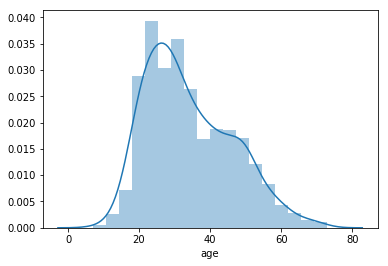

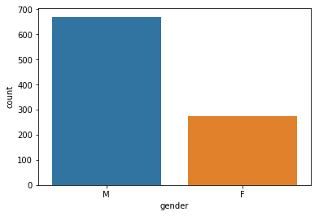

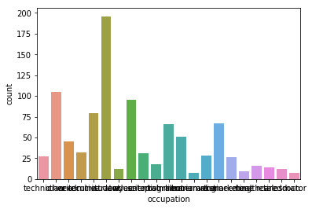

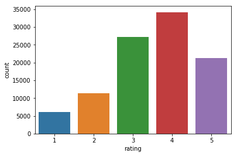

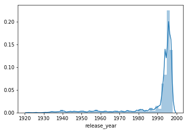

```python
# HINT: use distplot for age and countplot for gender,ratings,occupation.
# HINT: Please refer to the below snippet to understand how to get to release year from release date. You can use str.split()
# as depicted below
# Hint : Use displot without kde for release year or line plot showing year wise count.

# Distplot for age
sns.distplot(user['age'])
plt.show()

# Countplot for gender
sns.countplot(x="gender", data=user)
plt.show()

# Countplot for occupation
sns.countplot(x="occupation", data=user)
plt.show()

# Countplot for ratings
sns.countplot(x="rating", data=data)
plt.show()

# sns.distplot(item['release_year'])
release_year = item['release date'].str.split('-').str[2]
item['release_year'] = pd.to_numeric(release_year)
sns.distplot(item['release_year'])
```

```python
a = 'My*cat*is*brown'
print(a.split('*')[3])

#similarly, the release year needs to be taken out from release date

#also you can simply slice existing string to get the desired data, if we want to take out the colour of the cat

print(a[10:])
print(a[-5:])
```

```
brown
brown
brown
```

```python
#your answers here
item.head(10).groupby('release_year').head()
```

|  | movie id | movie title | release date | unknown | Action | Adventure | Animation | Childrens | Comedy | Crime | ... | Film-Noir | Horror | Musical | Mystery | Romance | Sci-Fi | Thriller | War | Western | release_year |
| --- | --- | --- | --- | --- | --- | --- | --- | --- | --- | --- | --- | --- | --- | --- | --- | --- | --- | --- | --- | --- | --- |
| 0 | 1 | Toy Story | 01-Jan-1995 | 0 | 0 | 0 | 1 | 1 | 1 | 0 | ... | 0 | 0 | 0 | 0 | 0 | 0 | 0 | 0 | 0 | 1995 |
| 1 | 2 | GoldenEye | 01-Jan-1995 | 0 | 1 | 1 | 0 | 0 | 0 | 0 | ... | 0 | 0 | 0 | 0 | 0 | 0 | 1 | 0 | 0 | 1995 |
| 2 | 3 | Four Rooms | 01-Jan-1995 | 0 | 0 | 0 | 0 | 0 | 0 | 0 | ... | 0 | 0 | 0 | 0 | 0 | 0 | 1 | 0 | 0 | 1995 |
| 3 | 4 | Get Shorty | 01-Jan-1995 | 0 | 1 | 0 | 0 | 0 | 1 | 0 | ... | 0 | 0 | 0 | 0 | 0 | 0 | 0 | 0 | 0 | 1995 |
| 4 | 5 | Copycat | 01-Jan-1995 | 0 | 0 | 0 | 0 | 0 | 0 | 1 | ... | 0 | 0 | 0 | 0 | 0 | 0 | 1 | 0 | 0 | 1995 |
| 9 | 10 | Richard III | 22-Jan-1996 | 0 | 0 | 0 | 0 | 0 | 0 | 0 | ... | 0 | 0 | 0 | 0 | 0 | 0 | 0 | 1 | 0 | 1996 |

6 rows × 23 columns

### 8. Visualize how popularity of genres has changed over the years - 10 marks

Note that you need to use the number of releases in a year as a parameter of popularity of a genre

Hint

1: you need to reach to a data frame where the release year is the index and the genre is the column names (one cell shows the number of release in a year in one genre) or vice versa. Once that is achieved, you can either use univariate plots or can use the heatmap to visualise all the changes over the years in one go.

Hint 2: Use groupby on the relevant column and use sum() on the same to find out the nuumber of releases in a year/genre.

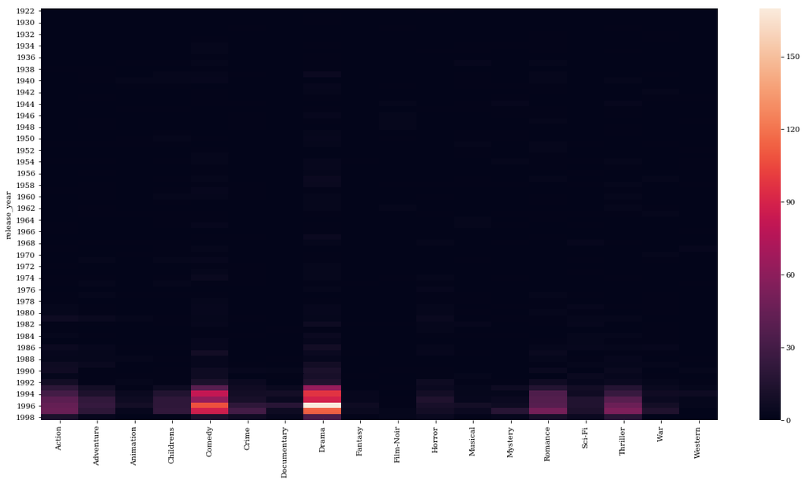

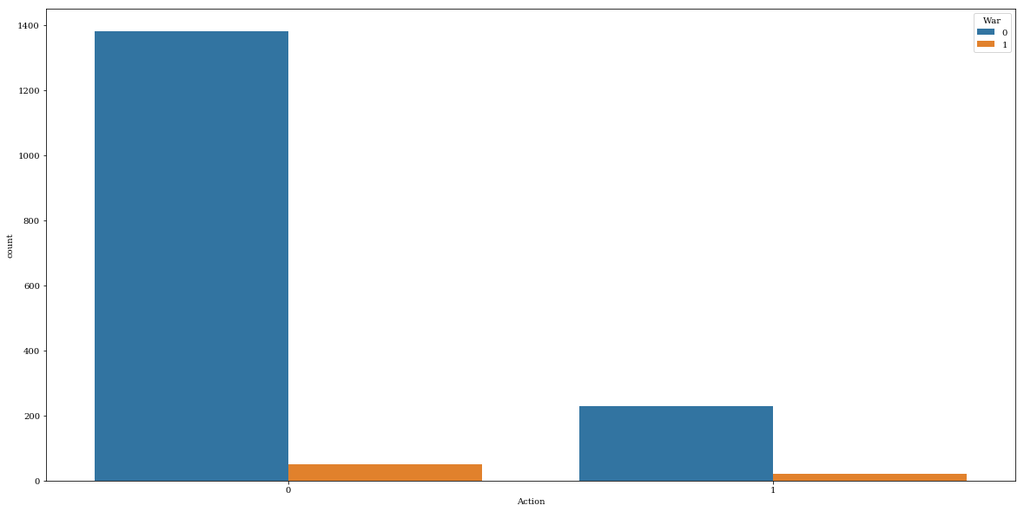

```python
#Your answer here
popularity_by_year = item.drop(['movie id', 'unknown'], axis=1).groupby('release_year').sum()
plt.rcParams['figure.figsize'] = (20.0, 10.0)
plt.rcParams['font.family'] = "serif"
sns.heatmap(popularity_by_year)
plt.show()

sns.countplot(x="Action", data=item, hue="War")
plt.show()
```

### 9. Find the top 25 movies according to average ratings such that each movie has number of ratings more than 100 - 10 marks

Hint :

1. First find the movies that have more than 100 ratings(use merge, groupby and count). Extract the movie titles in a list.
2. Find the average rating of all the movies and sort them in the descending order. You will have to use the .merge() function to reach to a data set through which you can get the names and the average rating.
3. Use isin(list obtained from 1) to filter out the movies which have more than 100 ratings.

Note: This question will need you to research about groupby and apply your findings. You can find more on groupby on https://realpython.com/pandas-groupby/.

```python
#your answer here
# Init data
mergeddata = pd.merge(item, data, on="movie id")

# Movies with more than 100 ratings
movies_ratings_count = mergeddata.groupby('movie title')['rating'].count()
movies_ratings_greater_than_100 = movies_ratings_count[movies_ratings_count > 100]
movies_ratings_greater_than_100_list = movies_ratings_greater_than_100.index.tolist()

# Average rating of movies
average_rating = mergeddata.groupby('movie title')['rating'].mean().sort_values(ascending=False)
average_rating = average_rating.to_frame()
average_rating['movie title'] = average_rating.index

# Filter out the movies which have more than 100 ratings
filtered_average_rating = average_rating.isin(movies_ratings_greater_than_100_list)

# Top 25 movies according to average ratings such that each movie has number of ratings more than 100
filtered_average_rating[filtered_average_rating['movie title'] == True].head(25).index
```

```
Index([u'Close Shave, A ', u'Schindler's List ', u'Wrong Trousers, The ',
       u'Casablanca ', u'Shawshank Redemption, The ', u'Rear Window ',
       u'Usual Suspects, The ', u'Star Wars ', u'12 Angry Men ',
       u'Citizen Kane ', u'To Kill a Mockingbird ',
       u'One Flew Over the Cuckoo's Nest ', u'Silence of the Lambs, The ',
       u'North by Northwest ', u'Godfather, The ', u'Secrets & Lies ',
       u'Good Will Hunting ', u'Manchurian Candidate, The ',
       u'Dr. Strangelove or: How I Learned to Stop Worrying and Love the Bomb ',
       u'Raiders of the Lost Ark ', u'Vertigo ', u'Titanic ',
       u'Lawrence of Arabia ', u'Maltese Falcon, The ',
       u'Empire Strikes Back, The '],
      dtype='object', name=u'movie title')
```

### 10. See gender distribution across different genres check for the validity of the below statements - 10 marks

- Men watch more drama than women
- Women watch more Sci-Fi than men
- Men watch more Romance than women
1. There is no need to conduct statistical tests around this. Just compare the percentages and comment on the validity of the above statements.
2. you might want ot use the .sum(), .div() function here.
3. Use number of ratings to validate the numbers. For example, if out of 4000 ratings received by women, 3000 are for drama, we will assume that 75% of the women watch drama.

#### Conclusion:

```python
fulldata = pd.merge(user, mergeddata, on='user id')

total_male_rating = fulldata.groupby(['gender']).count()['rating']['M']
total_female_rating = fulldata.groupby(['gender']).count()['rating']['F']

print 'Men'
print ''
print fulldata.groupby(['gender']).sum().loc['M'].div(total_male_rating)

print ''
print 'Women'
print fulldata.groupby(['gender']).sum().loc['F'].div(total_female_rating)
```

```
Men

user id        4.581611e+02
age            3.319755e+01
movie id       4.188109e+02
unknown        1.346747e-05
Action         2.713291e-01
Adventure      1.429168e-01
Animation      3.515009e-02
Childrens      6.666397e-02
Comedy         2.931060e-01
Crime          8.431983e-02
Documentary    7.689925e-03
Drama          3.890348e-01
Fantasy        1.331933e-02
Film-Noir      1.815415e-02
Horror         5.548597e-02
Musical        4.729775e-02
Mystery        5.294062e-02
Romance        1.831980e-01
Sci-Fi         1.360349e-01
Thriller       2.260649e-01
War            9.708699e-02
Western        1.997226e-02
rating         3.529298e+00
timestamp      8.834179e+08
Name: M, dtype: float64

Women
user id        4.750110e+02
age            3.231483e+01
movie id       4.449703e+02
unknown        0.000000e+00
Action         2.114383e-01
Adventure      1.220375e-01
Animation      3.865879e-02
Childrens      8.672002e-02
Comedy         3.134665e-01
Crime          6.970239e-02
Documentary    7.265522e-03
Drama          4.276945e-01
Fantasy        1.410366e-02
Film-Noir      1.495843e-02
Horror         4.650711e-02
Musical        5.602611e-02
Mystery        5.105292e-02
Romance        2.276012e-01
Sci-Fi         1.021447e-01
Thriller       1.976067e-01
War            8.504934e-02
Western        1.441448e-02
rating         3.531510e+00
timestamp      8.838516e+08
Name: F, dtype: float64
```

Based on the information above,

1) The statement: Men watch more drama than women, is invalid. Women watch more drama

2) The statement: Women watch more Sci-Fi than men, is invalid. Men watch more Sci-Fi

3) The statement: Men watch more Romance than women, is invalid. Woman watch more Romance